# Data Wrangling

Before diving into the practical aspects of data wrangling, let's first understand the real meaning of the term "wrangle." In everyday language, it means to take care of or deal with someone or something, usually when it is challenging. Now, let's apply this concept to the world of data.

In the data world, "wrangling" is the process of dealing with difficult or messy data. This typically involves cleaning up raw, erroneous, or incomplete data, which can often consume 90% of a data scientist's or data analyst's time. The goal is to transform that messy data into a nice, structured, and easy-to-use format. This is the essence of data wrangling.

At this point, you might assume that data wrangling is simply another term for data cleaning, data remediation, or data munging. While there is overlap, data wrangling encompasses a broader set of processes.

These processes are designed to transform raw data into a format that is more readily usable for analysis. The specific steps involved can differ from project to project, depending on the nature of the data and the goals we are trying to achieve.

Some of the example include:

- Merging mulitple data sources into a single dataset for analysis
- Identifying gaps in data and either filling or deleting them
- Unncessary data removal which are irrelevant to the project
- Understanding of outliers(analysing the importance of outliers)

Note: Though data cleaning and data wrangling used interchangeably, there is distinction.

- Data wrangling is the overal process of transformation raw data into a more usable form.
- Data cleaning is a critical step in the data wrangling process to remove inaccurate and inconsistent data.

[Source](https://online.hbs.edu/blog/post/data-wrangling)

# Example: Used Cars Pricing

For this process I have used "Automobile Dataset" from the link: https://archive.ics.uci.edu/ml/machine-learning-databases/autos/imports-85.data

# Objectives

- Handling missing values
- Correct data formatting
- Standardize and normalize data

```python
import pandas as pd
import matplotlib.pyplot as plt
```

### Reading dataset from the URL

```python
url =  'https://archive.ics.uci.edu/ml/machine-learning-databases/autos/imports-85.data'
df = pd.read_csv(url)
df
```

|  | 3 | ? | alfa-romero | gas | std | two | convertible | rwd | front | 88.60 | ... | 130 | mpfi | 3.47 | 2.68 | 9.00 | 111 | 5000 | 21 | 27 | 13495 |
| --- | --- | --- | --- | --- | --- | --- | --- | --- | --- | --- | --- | --- | --- | --- | --- | --- | --- | --- | --- | --- | --- |
| 0 | 3 | ? | alfa-romero | gas | std | two | convertible | rwd | front | 88.6 | ... | 130 | mpfi | 3.47 | 2.68 | 9.0 | 111 | 5000 | 21 | 27 | 16500 |
| 1 | 1 | ? | alfa-romero | gas | std | two | hatchback | rwd | front | 94.5 | ... | 152 | mpfi | 2.68 | 3.47 | 9.0 | 154 | 5000 | 19 | 26 | 16500 |
| 2 | 2 | 164 | audi | gas | std | four | sedan | fwd | front | 99.8 | ... | 109 | mpfi | 3.19 | 3.40 | 10.0 | 102 | 5500 | 24 | 30 | 13950 |
| 3 | 2 | 164 | audi | gas | std | four | sedan | 4wd | front | 99.4 | ... | 136 | mpfi | 3.19 | 3.40 | 8.0 | 115 | 5500 | 18 | 22 | 17450 |
| 4 | 2 | ? | audi | gas | std | two | sedan | fwd | front | 99.8 | ... | 136 | mpfi | 3.19 | 3.40 | 8.5 | 110 | 5500 | 19 | 25 | 15250 |
| ... | ... | ... | ... | ... | ... | ... | ... | ... | ... | ... | ... | ... | ... | ... | ... | ... | ... | ... | ... | ... | ... |
| 199 | -1 | 95 | volvo | gas | std | four | sedan | rwd | front | 109.1 | ... | 141 | mpfi | 3.78 | 3.15 | 9.5 | 114 | 5400 | 23 | 28 | 16845 |
| 200 | -1 | 95 | volvo | gas | turbo | four | sedan | rwd | front | 109.1 | ... | 141 | mpfi | 3.78 | 3.15 | 8.7 | 160 | 5300 | 19 | 25 | 19045 |
| 201 | -1 | 95 | volvo | gas | std | four | sedan | rwd | front | 109.1 | ... | 173 | mpfi | 3.58 | 2.87 | 8.8 | 134 | 5500 | 18 | 23 | 21485 |
| 202 | -1 | 95 | volvo | diesel | turbo | four | sedan | rwd | front | 109.1 | ... | 145 | idi | 3.01 | 3.40 | 23.0 | 106 | 4800 | 26 | 27 | 22470 |
| 203 | -1 | 95 | volvo | gas | turbo | four | sedan | rwd | front | 109.1 | ... | 141 | mpfi | 3.78 | 3.15 | 9.5 | 114 | 5400 | 19 | 25 | 22625 |

204 rows × 26 columns

As there is no header in this dataset, so let's add the header columns.

```python
headers = ["symboling","normalized-losses","make","fuel-type","aspiration", "num-of-doors","body-style",
         "drive-wheels","engine-location","wheel-base", "length","width","height","curb-weight","engine-type",
         "num-of-cylinders", "engine-size","fuel-system","bore","stroke","compression-ratio","horsepower",
         "peak-rpm","city-mpg","highway-mpg","price"]
```

```python
df.columns = headers
df.head()
```

|  | symboling | normalized-losses | make | fuel-type | aspiration | num-of-doors | body-style | drive-wheels | engine-location | wheel-base | ... | engine-size | fuel-system | bore | stroke | compression-ratio | horsepower | peak-rpm | city-mpg | highway-mpg | price |
| --- | --- | --- | --- | --- | --- | --- | --- | --- | --- | --- | --- | --- | --- | --- | --- | --- | --- | --- | --- | --- | --- |
| 0 | 3 | ? | alfa-romero | gas | std | two | convertible | rwd | front | 88.6 | ... | 130 | mpfi | 3.47 | 2.68 | 9.0 | 111 | 5000 | 21 | 27 | 16500 |
| 1 | 1 | ? | alfa-romero | gas | std | two | hatchback | rwd | front | 94.5 | ... | 152 | mpfi | 2.68 | 3.47 | 9.0 | 154 | 5000 | 19 | 26 | 16500 |
| 2 | 2 | 164 | audi | gas | std | four | sedan | fwd | front | 99.8 | ... | 109 | mpfi | 3.19 | 3.40 | 10.0 | 102 | 5500 | 24 | 30 | 13950 |
| 3 | 2 | 164 | audi | gas | std | four | sedan | 4wd | front | 99.4 | ... | 136 | mpfi | 3.19 | 3.40 | 8.0 | 115 | 5500 | 18 | 22 | 17450 |
| 4 | 2 | ? | audi | gas | std | two | sedan | fwd | front | 99.8 | ... | 136 | mpfi | 3.19 | 3.40 | 8.5 | 110 | 5500 | 19 | 25 | 15250 |

5 rows × 26 columns

We can clearly see the above there is '?'; Those may obviously may not reflect the essence in the data, which is gonna hinder furhter analysis.

**How to work with missing data?**

a. Identify missing data

b. Deal with missing data

c. Correct data format

# Identify and handle missing values

As above '?' has already identified pretty easily, so let's replace that with null values

```python
# library
import numpy as np

# replace "?" to NaN

df.replace('?', np.nan, inplace = True)
df.head(5)
```

|  | symboling | normalized-losses | make | fuel-type | aspiration | num-of-doors | body-style | drive-wheels | engine-location | wheel-base | ... | engine-size | fuel-system | bore | stroke | compression-ratio | horsepower | peak-rpm | city-mpg | highway-mpg | price |
| --- | --- | --- | --- | --- | --- | --- | --- | --- | --- | --- | --- | --- | --- | --- | --- | --- | --- | --- | --- | --- | --- |
| 0 | 3 | NaN | alfa-romero | gas | std | two | convertible | rwd | front | 88.6 | ... | 130 | mpfi | 3.47 | 2.68 | 9.0 | 111 | 5000 | 21 | 27 | 16500 |
| 1 | 1 | NaN | alfa-romero | gas | std | two | hatchback | rwd | front | 94.5 | ... | 152 | mpfi | 2.68 | 3.47 | 9.0 | 154 | 5000 | 19 | 26 | 16500 |
| 2 | 2 | 164 | audi | gas | std | four | sedan | fwd | front | 99.8 | ... | 109 | mpfi | 3.19 | 3.40 | 10.0 | 102 | 5500 | 24 | 30 | 13950 |
| 3 | 2 | 164 | audi | gas | std | four | sedan | 4wd | front | 99.4 | ... | 136 | mpfi | 3.19 | 3.40 | 8.0 | 115 | 5500 | 18 | 22 | 17450 |
| 4 | 2 | NaN | audi | gas | std | two | sedan | fwd | front | 99.8 | ... | 136 | mpfi | 3.19 | 3.40 | 8.5 | 110 | 5500 | 19 | 25 | 15250 |

5 rows × 26 columns

### Evaluating for missing Data

There are two ways to find out the missing data.

a. isnull()

b. notnull()

```python
df.isnull().head()
```

|  | symboling | normalized-losses | make | fuel-type | aspiration | num-of-doors | body-style | drive-wheels | engine-location | wheel-base | ... | engine-size | fuel-system | bore | stroke | compression-ratio | horsepower | peak-rpm | city-mpg | highway-mpg | price |
| --- | --- | --- | --- | --- | --- | --- | --- | --- | --- | --- | --- | --- | --- | --- | --- | --- | --- | --- | --- | --- | --- |
| 0 | False | True | False | False | False | False | False | False | False | False | ... | False | False | False | False | False | False | False | False | False | False |
| 1 | False | True | False | False | False | False | False | False | False | False | ... | False | False | False | False | False | False | False | False | False | False |
| 2 | False | False | False | False | False | False | False | False | False | False | ... | False | False | False | False | False | False | False | False | False | False |
| 3 | False | False | False | False | False | False | False | False | False | False | ... | False | False | False | False | False | False | False | False | False | False |
| 4 | False | True | False | False | False | False | False | False | False | False | ... | False | False | False | False | False | False | False | False | False | False |

5 rows × 26 columns

```python
df.notnull().head()
```

|  | symboling | normalized-losses | make | fuel-type | aspiration | num-of-doors | body-style | drive-wheels | engine-location | wheel-base | ... | engine-size | fuel-system | bore | stroke | compression-ratio | horsepower | peak-rpm | city-mpg | highway-mpg | price |
| --- | --- | --- | --- | --- | --- | --- | --- | --- | --- | --- | --- | --- | --- | --- | --- | --- | --- | --- | --- | --- | --- |
| 0 | True | False | True | True | True | True | True | True | True | True | ... | True | True | True | True | True | True | True | True | True | True |
| 1 | True | False | True | True | True | True | True | True | True | True | ... | True | True | True | True | True | True | True | True | True | True |
| 2 | True | True | True | True | True | True | True | True | True | True | ... | True | True | True | True | True | True | True | True | True | True |
| 3 | True | True | True | True | True | True | True | True | True | True | ... | True | True | True | True | True | True | True | True | True | True |
| 4 | True | False | True | True | True | True | True | True | True | True | ... | True | True | True | True | True | True | True | True | True | True |

5 rows × 26 columns

The output is a boolean value indicating whether the value that is passed into the argument:

- is missing data in case of **isnull()**
- not missing data in case of **notnull()**

Let's visulise above boolean expression into another format using **sum()** method, which returns the summation of total available missing values.

```python
df.isnull().sum()
```

```
symboling             0
normalized-losses    40
make                  0
fuel-type             0
aspiration            0
num-of-doors          2
body-style            0
drive-wheels          0
engine-location       0
wheel-base            0
length                0
width                 0
height                0
curb-weight           0
engine-type           0
num-of-cylinders      0
engine-size           0
fuel-system           0
bore                  4
stroke                4
compression-ratio     0
horsepower            2
peak-rpm              2
city-mpg              0
highway-mpg           0
price                 4
dtype: int64
```

```python
# let's set above missing values in the new variable 'missing_data'

missing_data = df.isnull()
```

```python
#for column in missing_data.columns.values.tolist():
#  print(column)
#  print("Missing data in", missing_data[column].value_counts())
#  print('')
```

### Deal with missing data:

1. Drop data:
- Drop the whole row
- Drop the whole column
2. Replace data
- Replace with mean value
- Replace by frequency
- replace it based on other functions

Notes:

We should only drop the whole columns if most entries in the column are empty. In the data set, none of the columns are empty enough to drop entirely.

**Replace by mean:**

**Replace by Frequecny:**

- "num-of-doors": 2 missing data, replace with Frequency

**Drop the whole row:**

- "price": 4 missing data, simple delete the whole row
  - reason: For the prediction to price, we cannot use any data entry without price data, so better to remove them for now.

### Calculate the mean value for the 'normalized-losses' column

Before doing this, first we check the datatypes with __info() method. __

```python
df.info()
```

```
<class 'pandas.core.frame.DataFrame'>
RangeIndex: 204 entries, 0 to 203
Data columns (total 26 columns):
 #   Column             Non-Null Count  Dtype
---  ------             --------------  -----
 0   symboling          204 non-null    int64
 1   normalized-losses  164 non-null    object
 2   make               204 non-null    object
 3   fuel-type          204 non-null    object
 4   aspiration         204 non-null    object
 5   num-of-doors       202 non-null    object
 6   body-style         204 non-null    object
 7   drive-wheels       204 non-null    object
 8   engine-location    204 non-null    object
 9   wheel-base         204 non-null    float64
```

[output cut: 18 more lines]

To calculate the mean value, string columns has to be converted into numeric type, which could be int or float depending upon the attributes.

For this we are coverting into float.

```python
avg_norm_loss = df['normalized-losses'].astype('float').mean()
avg_norm_loss
```

```
np.float64(122.0)
```

### Replace "NaN with mean value

```python
# replace on Normalised losses
df['normalized-losses'].replace(np.nan,avg_norm_loss)
```

```
0      122.0
1      122.0
2        164
3        164
4      122.0
       ...
199       95
200       95
201       95
202       95
203       95
Name: normalized-losses, Length: 204, dtype: object
```

```python
# replace on bore column
avg_bore = df['bore'].astype('float').mean()

df.loc[:, 'bore'] = df['bore'].replace(np.nan, avg_bore)
df.head()
```

|  | symboling | normalized-losses | make | fuel-type | aspiration | num-of-doors | body-style | drive-wheels | engine-location | wheel-base | ... | engine-size | fuel-system | bore | stroke | compression-ratio | horsepower | peak-rpm | city-mpg | highway-mpg | price |
| --- | --- | --- | --- | --- | --- | --- | --- | --- | --- | --- | --- | --- | --- | --- | --- | --- | --- | --- | --- | --- | --- |
| 0 | 3 | NaN | alfa-romero | gas | std | two | convertible | rwd | front | 88.6 | ... | 130 | mpfi | 3.47 | 2.68 | 9.0 | 111 | 5000 | 21 | 27 | 16500 |
| 1 | 1 | NaN | alfa-romero | gas | std | two | hatchback | rwd | front | 94.5 | ... | 152 | mpfi | 2.68 | 3.47 | 9.0 | 154 | 5000 | 19 | 26 | 16500 |
| 2 | 2 | 164 | audi | gas | std | four | sedan | fwd | front | 99.8 | ... | 109 | mpfi | 3.19 | 3.40 | 10.0 | 102 | 5500 | 24 | 30 | 13950 |
| 3 | 2 | 164 | audi | gas | std | four | sedan | 4wd | front | 99.4 | ... | 136 | mpfi | 3.19 | 3.40 | 8.0 | 115 | 5500 | 18 | 22 | 17450 |
| 4 | 2 | NaN | audi | gas | std | two | sedan | fwd | front | 99.8 | ... | 136 | mpfi | 3.19 | 3.40 | 8.5 | 110 | 5500 | 19 | 25 | 15250 |

5 rows × 26 columns

```python
# replace on stroke column

avg_stroke = df['stroke'].astype('f').mean()

df['stroke'].replace(np.nan, avg_stroke)
```

```
0      2.68
1      3.47
2      3.40
3      3.40
4      3.40
       ...
199    3.15
200    3.15
201    2.87
202    3.40
203    3.15
Name: stroke, Length: 204, dtype: object
```

```python
#replace on horsepower

avg_horsepower = df['horsepower'].astype('f').mean()

df['horsepower'].replace(np.nan, avg_horsepower)
```

```
0      111
1      154
2      102
3      115
4      110
      ...
199    114
200    160
201    134
202    106
203    114
Name: horsepower, Length: 204, dtype: object
```

```python
# replace on peakrpm
avg_peakrpm = df['peak-rpm'].astype('f').mean()
df['peak-rpm'].replace(np.nan, avg_peakrpm)
```

```
0      5000
1      5000
2      5500
3      5500
4      5500
       ...
199    5400
200    5300
201    5500
202    4800
203    5400
Name: peak-rpm, Length: 204, dtype: object
```

```python
df['peak-rpm'].value_counts()
```

```
peak-rpm
5500    37
4800    36
5000    26
5200    23
5400    13
6000     9
5800     7
4500     7
5250     7
4150     5
4200     5
4350     4
4750     4
5100     3
4250     3
4400     3
5900     3
6600     2
4650     1
5750     1
5600     1
4900     1
5300     1
Name: count, dtype: int64
```

### Replace missing values by the most Frequent

How would we know now, by which number should we replace the nan values in case of categorical variables?

- Check which categorical attributes has higher frequency values with two method:
- **value_counts()** : value_counts() method is used to see which values are present in a column.
- **idxmax()** : use to see the most common type or frequent one automatically without need to see any other values. Just quikly check which has got the higest count or common one.
  - To use idxmax, add this "idxmax" method to the end of the 'value_counts()"

```python
df['num-of-doors'].value_counts()
```

```
num-of-doors
four    114
two      88
Name: count, dtype: int64
```

- Four doors are the most common type.

```python
df['num-of-doors'].value_counts().idxmax()
```

```
'four'
```

```python
# Replace with 'four'

df['num-of-doors'].replace(np.nan, 'four')
```

```
0       two
1       two
2      four
3      four
4       two
       ...
199    four
200    four
201    four
202    four
203    four
Name: num-of-doors, Length: 204, dtype: object
```

### Drop the rows entirely

```python
# Drop whole row having NaN in Price column
df.dropna(subset=['price'], axis = 0, inplace= True)
```

**Note: We have to reset the index when rows are dropped (as in the previous step), the original row indices are retained. This method gives the DataFrame a new, sequential index starting from 0. There's gonna be old index as it is, with this argument, (drop = True) ensures that the old index (before resetting) is dropped.**

```python
df.reset_index(drop= True, inplace= True)
```

```python
#let's explore our data
df
```

|  | symboling | normalized-losses | make | fuel-type | aspiration | num-of-doors | body-style | drive-wheels | engine-location | wheel-base | ... | engine-size | fuel-system | bore | stroke | compression-ratio | horsepower | peak-rpm | city-mpg | highway-mpg | price |
| --- | --- | --- | --- | --- | --- | --- | --- | --- | --- | --- | --- | --- | --- | --- | --- | --- | --- | --- | --- | --- | --- |
| 0 | 3 | NaN | alfa-romero | gas | std | two | convertible | rwd | front | 88.6 | ... | 130 | mpfi | 3.47 | 2.68 | 9.0 | 111 | 5000 | 21 | 27 | 16500 |
| 1 | 1 | NaN | alfa-romero | gas | std | two | hatchback | rwd | front | 94.5 | ... | 152 | mpfi | 2.68 | 3.47 | 9.0 | 154 | 5000 | 19 | 26 | 16500 |
| 2 | 2 | 164 | audi | gas | std | four | sedan | fwd | front | 99.8 | ... | 109 | mpfi | 3.19 | 3.40 | 10.0 | 102 | 5500 | 24 | 30 | 13950 |
| 3 | 2 | 164 | audi | gas | std | four | sedan | 4wd | front | 99.4 | ... | 136 | mpfi | 3.19 | 3.40 | 8.0 | 115 | 5500 | 18 | 22 | 17450 |
| 4 | 2 | NaN | audi | gas | std | two | sedan | fwd | front | 99.8 | ... | 136 | mpfi | 3.19 | 3.40 | 8.5 | 110 | 5500 | 19 | 25 | 15250 |
| ... | ... | ... | ... | ... | ... | ... | ... | ... | ... | ... | ... | ... | ... | ... | ... | ... | ... | ... | ... | ... | ... |
| 195 | -1 | 95 | volvo | gas | std | four | sedan | rwd | front | 109.1 | ... | 141 | mpfi | 3.78 | 3.15 | 9.5 | 114 | 5400 | 23 | 28 | 16845 |
| 196 | -1 | 95 | volvo | gas | turbo | four | sedan | rwd | front | 109.1 | ... | 141 | mpfi | 3.78 | 3.15 | 8.7 | 160 | 5300 | 19 | 25 | 19045 |
| 197 | -1 | 95 | volvo | gas | std | four | sedan | rwd | front | 109.1 | ... | 173 | mpfi | 3.58 | 2.87 | 8.8 | 134 | 5500 | 18 | 23 | 21485 |
| 198 | -1 | 95 | volvo | diesel | turbo | four | sedan | rwd | front | 109.1 | ... | 145 | idi | 3.01 | 3.40 | 23.0 | 106 | 4800 | 26 | 27 | 22470 |
| 199 | -1 | 95 | volvo | gas | turbo | four | sedan | rwd | front | 109.1 | ... | 141 | mpfi | 3.78 | 3.15 | 9.5 | 114 | 5400 | 19 | 25 | 22625 |

200 rows × 26 columns

Four rows has been deleted (200 rows) from the orignal data(204 rows)

```python
# once again check the missing values
df.isna().sum()
```

```
symboling             0
normalized-losses    36
make                  0
fuel-type             0
aspiration            0
num-of-doors          2
body-style            0
drive-wheels          0
engine-location       0
wheel-base            0
length                0
width                 0
height                0
curb-weight           0
engine-type           0
num-of-cylinders      0
engine-size           0
fuel-system           0
bore                  0
stroke                4
compression-ratio     0
horsepower            2
peak-rpm              2
city-mpg              0
highway-mpg           0
price                 0
dtype: int64
```

### Correct data format

This is also the another part of data cleaning process, which is also called **data Wrangling** and it ensures taht all data is in the correct format( int, float, text......)

- To check the data type, use **dtype()** method.
- To change the datatype, use **astype()** method as done previously above.

Don't be confused that previously we have not made changes in the original dataset's datatypes. We just created a new variable and perform operation and store the value in new variable of 'float' type.

```python
# checkout the datatypes

df.dtypes
```

```
symboling              int64
normalized-losses     object
make                  object
fuel-type             object
aspiration            object
num-of-doors          object
body-style            object
drive-wheels          object
engine-location       object
wheel-base           float64
length               float64
width                float64
height               float64
curb-weight            int64
engine-type           object
num-of-cylinders      object
engine-size            int64
fuel-system           object
bore                  object
stroke                object
compression-ratio    float64
horsepower            object
peak-rpm              object
city-mpg               int64
highway-mpg            int64
price                 object
dtype: object
```

In short:

- Numerical variables should be 'float' or 'int' type.
- Categorical variables should be of 'object' type.

'bore', 'stroke' are of object type, which should be converted to proper format either 'int' or 'float' as per the requirements.

### Convert data types to proper format

And this time let's make it changes in the original datasets.

```python
# change into float type
df[['bore','stroke']]=df[['bore','stroke']].astype('f')
df[['price','peak-rpm']] = df[['price','peak-rpm']].astype('float')
```

```python
# Check to int type

df[['normalized-losses']] = df[['normalized-losses']].astype('int')
```

[output not shown]

[output cut: 10 more lines]

[output not shown]

```python
df.dtypes
```

```
symboling              int64
normalized-losses      int64
make                  object
fuel-type             object
aspiration            object
num-of-doors          object
body-style            object
drive-wheels          object
engine-location       object
wheel-base           float64
length               float64
width                float64
height               float64
curb-weight            int64
engine-type           object
num-of-cylinders      object
engine-size            int64
fuel-system           object
bore                 float32
stroke               float32
compression-ratio    float64
horsepower            object
peak-rpm             float64
city-mpg               int64
highway-mpg            int64
price                float64
dtype: object
```

```python
df['bore'].dtype
```

```
dtype('float32')
```

### Data Standardization

It is a process of transforming data into a common format. Often data has different unit or scales.

For example: a. Suppose in the dataset, there is one column "price" which is measured in "dollars" and another in "meters", the features with larger values might disproprotionately affect the model unless both are standardised.

Data standardization is a preprocessing step, where the features(data) are transfomred to have **zero mean** and **unit variance(1)**, which ensures that all features contribute equally to the model's training process.

Why?

various reasons:

a. When features are on different scales, machine learning algorithms may place more importance on features with larger scales. Standardization ensures that each feature contributes equally

b. Improves Model Performance: Many algorithms like logistic regression, support vector machines (SVMs), and k-nearest neighbors (KNN) perform better when features are standardized.

c. Gradient-based methods: Models like linear regression, neural networks, and gradient descent also benefit from standardized data since it ensures faster and more stable convergence.

```python
import pandas as pd
example = pd.DataFrame({
    'Name' : ['Suresh', 'Mahesh', 'Ramesh', 'Sailesh'],
    'Height(cm)' : [170, 160, 180, 150],
    'Weight(kg)' : [65, 70, 80, 55]

})
example
```

|  | Name | Height(cm) | Weight(kg) |
| --- | --- | --- | --- |
| 0 | Suresh | 170 | 65 |
| 1 | Mahesh | 160 | 70 |
| 2 | Ramesh | 180 | 80 |
| 3 | Sailesh | 150 | 55 |

The features are on diffeent scales(height in cm and weight in kg), and has large values discripancies.

The formula for standardization is:

$$ z = (x - \mu )/ \sigma $$

Where,

- x is the orignal feature value
- $\mu$ is the mean of the feature
- $\sigma$ is the standard deviation of the feature

```python
# For now we are doing all by step by step, later we are gonna use function directly.

# calculate the mean of the Height and weight

height_mean = example['Height(cm)'].mean()
weight_mean = example['Weight(kg)'].mean()
print(height_mean)
print(weight_mean)
```

```
165.0
67.5
```

```python
# calculate the standard deviation of Height and Weight

height_std = example['Height(cm)'].std()
weigth_std = example['Weight(kg)'].std()
```

```python
# calculate z value for height

example['Height(cm)'] = (example['Height(cm)'] - height_mean)/ height_std
example['Height(cm)']
```

```
0    0.387298
1   -0.387298
2    1.161895
3   -1.161895
Name: Height(cm), dtype: float64
```

```python
# calcualte z value for weight

example['Weight(kg)'] = (example['Weight(kg)'] - weight_mean)/ weigth_std
example['Weight(kg)']
```

```
0   -0.240192
1    0.240192
2    1.200961
3   -1.200961
Name: Weight(kg), dtype: float64
```

```python
example
```

|  | Name | Height(cm) | Weight(kg) |
| --- | --- | --- | --- |
| 0 | Suresh | 0.387298 | -0.240192 |
| 1 | Mahesh | -0.387298 | 0.240192 |
| 2 | Ramesh | 1.161895 | 1.200961 |
| 3 | Sailesh | -1.161895 | -1.200961 |

### StandardScaler

We have library calleld StandardScaler which can easily make our data standaridized.

```python
from sklearn.preprocessing import StandardScaler

import pandas as pd
example = pd.DataFrame({
    'Name' : ['Suresh', 'Mahesh', 'Ramesh', 'Sailesh'],
    'Height(cm)' : [170, 160, 180, 150],
    'Weight(kg)' : [65, 70, 80, 55]

})
example

# Initilizse the StandardScaler

scaler = StandardScaler()

# Standardise the data
new_df = example[['Height(cm)', 'Weight(kg)']]
new_df[['height_std', 'weight_std']] = scaler.fit_transform(new_df)
new_df
```

|  | Height(cm) | Weight(kg) | height_std | weight_std |
| --- | --- | --- | --- | --- |
| 0 | 170 | 65 | 0.447214 | -0.27735 |
| 1 | 160 | 70 | -0.447214 | 0.27735 |
| 2 | 180 | 80 | 1.341641 | 1.38675 |
| 3 | 150 | 55 | -1.341641 | -1.38675 |

### Moving to our previous main example

In the our dataset, there is fuel consumptions columns "city-mpg" and "highway-mpg" represented by mpg(miles per gallon) unit. But these need to be transformed to "L/100km".

```python
df.head()
```

|  | symboling | normalized-losses | make | fuel-type | aspiration | num-of-doors | body-style | drive-wheels | engine-location | wheel-base | ... | engine-size | fuel-system | bore | stroke | compression-ratio | horsepower | peak-rpm | city-mpg | highway-mpg | price |
| --- | --- | --- | --- | --- | --- | --- | --- | --- | --- | --- | --- | --- | --- | --- | --- | --- | --- | --- | --- | --- | --- |
| 0 | 3 | 122 | alfa-romero | gas | std | two | convertible | rwd | front | 88.6 | ... | 130 | mpfi | 3.47 | 2.68 | 9.0 | 111 | 5000.0 | 21 | 27 | 16500.0 |
| 1 | 1 | 122 | alfa-romero | gas | std | two | hatchback | rwd | front | 94.5 | ... | 152 | mpfi | 2.68 | 3.47 | 9.0 | 154 | 5000.0 | 19 | 26 | 16500.0 |
| 2 | 2 | 164 | audi | gas | std | four | sedan | fwd | front | 99.8 | ... | 109 | mpfi | 3.19 | 3.40 | 10.0 | 102 | 5500.0 | 24 | 30 | 13950.0 |
| 3 | 2 | 164 | audi | gas | std | four | sedan | 4wd | front | 99.4 | ... | 136 | mpfi | 3.19 | 3.40 | 8.0 | 115 | 5500.0 | 18 | 22 | 17450.0 |
| 4 | 2 | 122 | audi | gas | std | two | sedan | fwd | front | 99.8 | ... | 136 | mpfi | 3.19 | 3.40 | 8.5 | 110 | 5500.0 | 19 | 25 | 15250.0 |

5 rows × 26 columns

```python
df['city-L/100km'] = 255/df["city-mpg"]
df.head()
```

|  | symboling | normalized-losses | make | fuel-type | aspiration | num-of-doors | body-style | drive-wheels | engine-location | wheel-base | ... | fuel-system | bore | stroke | compression-ratio | horsepower | peak-rpm | city-mpg | highway-mpg | price | city-L/100km |
| --- | --- | --- | --- | --- | --- | --- | --- | --- | --- | --- | --- | --- | --- | --- | --- | --- | --- | --- | --- | --- | --- |
| 0 | 3 | 122 | alfa-romero | gas | std | two | convertible | rwd | front | 88.6 | ... | mpfi | 3.47 | 2.68 | 9.0 | 111 | 5000.0 | 21 | 27 | 16500.0 | 12.142857 |
| 1 | 1 | 122 | alfa-romero | gas | std | two | hatchback | rwd | front | 94.5 | ... | mpfi | 2.68 | 3.47 | 9.0 | 154 | 5000.0 | 19 | 26 | 16500.0 | 13.421053 |
| 2 | 2 | 164 | audi | gas | std | four | sedan | fwd | front | 99.8 | ... | mpfi | 3.19 | 3.40 | 10.0 | 102 | 5500.0 | 24 | 30 | 13950.0 | 10.625000 |
| 3 | 2 | 164 | audi | gas | std | four | sedan | 4wd | front | 99.4 | ... | mpfi | 3.19 | 3.40 | 8.0 | 115 | 5500.0 | 18 | 22 | 17450.0 | 14.166667 |
| 4 | 2 | 122 | audi | gas | std | two | sedan | fwd | front | 99.8 | ... | mpfi | 3.19 | 3.40 | 8.5 | 110 | 5500.0 | 19 | 25 | 15250.0 | 13.421053 |

5 rows × 27 columns

```python
# transform mpg to L/100km in the column "highway-mpg"

df['highway-L/100km'] = 255 / df['highway-mpg']
df.head()
```

|  | symboling | normalized-losses | make | fuel-type | aspiration | num-of-doors | body-style | drive-wheels | engine-location | wheel-base | ... | bore | stroke | compression-ratio | horsepower | peak-rpm | city-mpg | highway-mpg | price | city-L/100km | highway-L/100km |
| --- | --- | --- | --- | --- | --- | --- | --- | --- | --- | --- | --- | --- | --- | --- | --- | --- | --- | --- | --- | --- | --- |
| 0 | 3 | 122 | alfa-romero | gas | std | two | convertible | rwd | front | 88.6 | ... | 3.47 | 2.68 | 9.0 | 111 | 5000.0 | 21 | 27 | 16500.0 | 12.142857 | 9.444444 |
| 1 | 1 | 122 | alfa-romero | gas | std | two | hatchback | rwd | front | 94.5 | ... | 2.68 | 3.47 | 9.0 | 154 | 5000.0 | 19 | 26 | 16500.0 | 13.421053 | 9.807692 |
| 2 | 2 | 164 | audi | gas | std | four | sedan | fwd | front | 99.8 | ... | 3.19 | 3.40 | 10.0 | 102 | 5500.0 | 24 | 30 | 13950.0 | 10.625000 | 8.500000 |
| 3 | 2 | 164 | audi | gas | std | four | sedan | 4wd | front | 99.4 | ... | 3.19 | 3.40 | 8.0 | 115 | 5500.0 | 18 | 22 | 17450.0 | 14.166667 | 11.590909 |
| 4 | 2 | 122 | audi | gas | std | two | sedan | fwd | front | 99.8 | ... | 3.19 | 3.40 | 8.5 | 110 | 5500.0 | 19 | 25 | 15250.0 | 13.421053 | 10.200000 |

5 rows × 28 columns

As there is both old and new attributes present in the dataset.

So, we should do as below to reflect in the original dataset.

```python
# transform the data
df['highway-mpg'] = 235 / df['highway-mpg']

df.rename(columns= {'highway-mpg': 'highway-L/100km'}, inplace=True)
df.head()
```

|  | symboling | normalized-losses | make | fuel-type | aspiration | num-of-doors | body-style | drive-wheels | engine-location | wheel-base | ... | bore | stroke | compression-ratio | horsepower | peak-rpm | city-mpg | highway-L/100km | price | city-L/100km | highway-L/100km |
| --- | --- | --- | --- | --- | --- | --- | --- | --- | --- | --- | --- | --- | --- | --- | --- | --- | --- | --- | --- | --- | --- |
| 0 | 3 | 122 | alfa-romero | gas | std | two | convertible | rwd | front | 88.6 | ... | 3.47 | 2.68 | 9.0 | 111 | 5000.0 | 21 | 8.703704 | 16500.0 | 12.142857 | 9.444444 |
| 1 | 1 | 122 | alfa-romero | gas | std | two | hatchback | rwd | front | 94.5 | ... | 2.68 | 3.47 | 9.0 | 154 | 5000.0 | 19 | 9.038462 | 16500.0 | 13.421053 | 9.807692 |
| 2 | 2 | 164 | audi | gas | std | four | sedan | fwd | front | 99.8 | ... | 3.19 | 3.40 | 10.0 | 102 | 5500.0 | 24 | 7.833333 | 13950.0 | 10.625000 | 8.500000 |
| 3 | 2 | 164 | audi | gas | std | four | sedan | 4wd | front | 99.4 | ... | 3.19 | 3.40 | 8.0 | 115 | 5500.0 | 18 | 10.681818 | 17450.0 | 14.166667 | 11.590909 |
| 4 | 2 | 122 | audi | gas | std | two | sedan | fwd | front | 99.8 | ... | 3.19 | 3.40 | 8.5 | 110 | 5500.0 | 19 | 9.400000 | 15250.0 | 13.421053 | 10.200000 |

5 rows × 28 columns

```python
# transform for city-mpg also

df['city-mpg'] = 235/ df['city-mpg']

#rename
df.rename(columns= {'city-mpg':'city-L/100km'}, inplace= True)
df.head()
```

|  | symboling | normalized-losses | make | fuel-type | aspiration | num-of-doors | body-style | drive-wheels | engine-location | wheel-base | ... | bore | stroke | compression-ratio | horsepower | peak-rpm | city-L/100km | highway-L/100km | price | city-L/100km | highway-L/100km |
| --- | --- | --- | --- | --- | --- | --- | --- | --- | --- | --- | --- | --- | --- | --- | --- | --- | --- | --- | --- | --- | --- |
| 0 | 3 | 122 | alfa-romero | gas | std | two | convertible | rwd | front | 88.6 | ... | 3.47 | 2.68 | 9.0 | 111 | 5000.0 | 11.190476 | 8.703704 | 16500.0 | 12.142857 | 9.444444 |
| 1 | 1 | 122 | alfa-romero | gas | std | two | hatchback | rwd | front | 94.5 | ... | 2.68 | 3.47 | 9.0 | 154 | 5000.0 | 12.368421 | 9.038462 | 16500.0 | 13.421053 | 9.807692 |
| 2 | 2 | 164 | audi | gas | std | four | sedan | fwd | front | 99.8 | ... | 3.19 | 3.40 | 10.0 | 102 | 5500.0 | 9.791667 | 7.833333 | 13950.0 | 10.625000 | 8.500000 |
| 3 | 2 | 164 | audi | gas | std | four | sedan | 4wd | front | 99.4 | ... | 3.19 | 3.40 | 8.0 | 115 | 5500.0 | 13.055556 | 10.681818 | 17450.0 | 14.166667 | 11.590909 |
| 4 | 2 | 122 | audi | gas | std | two | sedan | fwd | front | 99.8 | ... | 3.19 | 3.40 | 8.5 | 110 | 5500.0 | 12.368421 | 9.400000 | 15250.0 | 13.421053 | 10.200000 |

5 rows × 28 columns

## Data Normalization

It is a process of transforming values of several variables into a similar range or rescaling numerical data to a common scale, typically within the range of 0 to 1.

Goal:

- To ensure that all features have the same scale

When to use:

- when data doesnot follow a normal distribution
- Need the features to be on the same scale for distance based algorithms (KNN or clustering)

The formula for Normalization is and on the basis of **Min_Max Normalization**:

$$X_{normalized} = \frac{X - X_{min}}{X_{max} - X_{min}} $$

Where,

- X is the orignal value
- $X_{min}$ is the minimum value of the feature
- $X_{max}$ is the maximum value of the feature

#### Once again we are using the 'example' dataset done in the above.

```python
import pandas as pd
example = pd.DataFrame({
    'Name' : ['Suresh', 'Mahesh', 'Ramesh', 'Sailesh'],
    'Height(cm)' : [170, 160, 180, 150],
    'Weight(kg)' : [65, 70, 80, 55]

})
example
```

|  | Name | Height(cm) | Weight(kg) |
| --- | --- | --- | --- |
| 0 | Suresh | 170 | 65 |
| 1 | Mahesh | 160 | 70 |
| 2 | Ramesh | 180 | 80 |
| 3 | Sailesh | 150 | 55 |

```python
example[['Height(cm)']].min()
example[['Weight(kg)']].min()
```

```
Weight(kg)    55
dtype: int64
```

```python
min_height=np.min(example['Height(cm)'])
max_height = np.max(example['Height(cm)'])

min_Weight=np.min(example['Weight(kg)'])
max_Weight = np.max(example['Weight(kg)'])
```

```python
example['Height(cm)_normalised'] = (example['Height(cm)'] - min_height) /(max_height - min_height)
example['Weight(kg)_normalised'] = (example['Weight(kg)'] - min_Weight) /(max_Weight - min_Weight)
```

```python
example
```

|  | Name | Height(cm) | Weight(kg) | Height(cm)_normalised | Weight(kg)_normalised |
| --- | --- | --- | --- | --- | --- |
| 0 | Suresh | 170 | 65 | 0.666667 | 0.4 |
| 1 | Mahesh | 160 | 70 | 0.333333 | 0.6 |
| 2 | Ramesh | 180 | 80 | 1.000000 | 1.0 |
| 3 | Sailesh | 150 | 55 | 0.000000 | 0.0 |

#### Normalization with Min-Max Scaler

```python
# in the above example dataset
import pandas as pd
from sklearn.preprocessing import MinMaxScaler

# Sample DataFrame
data = {'Height(cm)': [170, 160, 180, 150],
        'Weight(kg)': [65, 70, 80, 55]}
example = pd.DataFrame(data)

# Initialize the MinMaxScaler
scaler = MinMaxScaler()

# Fit and transform the data using MinMaxScaler
example_normalized = pd.DataFrame(scaler.fit_transform(example), columns=example.columns)

print(example_normalized)
```

```
   Height(cm)  Weight(kg)
0    0.666667         0.4
1    0.333333         0.6
2    1.000000         1.0
3    0.000000         0.0
```

#### Apply min-max scaler to our previous dataset

```python
from sklearn.preprocessing import MinMaxScaler

# select numerical columns to normalize
numerical_cols = ['normalized-losses', 'wheel-base', 'engine-size', 'bore', 'stroke',
                  'compression-ratio', 'horsepower', 'peak-rpm', 'city-L/100km',
                  'highway-L/100km', 'price']

# Initialize the MinMaxScaler
scaler = MinMaxScaler()

#NOrmalize the selected numerical columns.
#df[numerical_cols] = scaler.fit_transform(df[numerical_cols])

# view the normalized dataframe
#df.head()
```

### Binning

This is a process of transforming continuous numerical variables into discrete categorical 'bins' for grouped analysis, by defining intervals(bins) and assigning each value to a corresponding bin.

It helps in reducing the impact of minor observation errors and also simplify model-building by reducing the number of distinct values.

Suppose, we are interested to know the price difference between cars with high horsepower, medium horsepower and little horspower of three types. We can rearrange them into three bins.

For this, we use **cut** method.

```python
df['horsepower'].unique()
```

```
array(['111', '154', '102', '115', '110', '140', '101', '121', '182',
       '48', '70', '68', '88', '145', '58', '76', '60', '86', '100', '78',
       '90', '176', '262', '135', '84', '64', '120', '72', '123', '155',
       '184', '175', '116', '69', '55', '97', '152', '160', '200', '95',
       '142', '143', '207', nan, '73', '82', '94', '62', '56', '112',
       '92', '161', '156', '52', '85', '114', '162', '134', '106'],
      dtype=object)
```

```python
# concert above data to correct format as 'horsepower' is in object format
#df['horsepower'] = df['horsepower'].astype('float')


df['horsepower'] = pd.to_numeric(df['horsepower'], errors= 'coerce')
```

#### Plot the historgram of horsepower to check the distribution

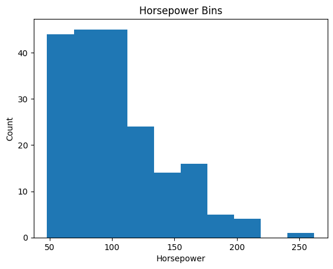

```python
import matplotlib.pyplot as plt  # Common way to import pyplot

plt.hist(df['horsepower'])

plt.xlabel('Horsepower')
plt.ylabel('Count')
plt.title('Horsepower Bins')
plt.show()
```

- Most cars have horsepower between 50 and 100.
- A smaller number of cars have higher horsepower, with few cars above 200 horsepower.

### With bininig

To bin, we __pd.cut()__method to bin.

- Parameters inside cut() function would be:

a. Total bins

b. labels: which is group names(What variables which describes that divided bins)

c. include_lowest = True:

a. Three bins of equal size bandwidth using Numply's **linspace(start_values, end_value, numbers_generated)** function.

```python
bins = np.linspace(min(df['horsepower']), max(df['horsepower']), 4)
bins
```

```
array([ 48.        , 119.33333333, 190.66666667, 262.        ])
```

```python
group_names = ['low', 'medium', 'high']
```

- Since we want to include the minimum value of horsepower, so we set min value with min() funtion and same goes for max value with max() function.
- As we are building 3 bins of equal length, we need 4 dividers, binwidth is 4.

```python
# apply cut method to determin what each value of df['horsepower'] belongs to

df['horsepower_binned'] = pd.cut(df['horsepower'], bins, group_names, include_lowest = True)
df[['horsepower', 'horsepower_binned']].head()
```

|  | horsepower | horsepower_binned |
| --- | --- | --- |
| 0 | 111.0 | (47.999, 119.333] |
| 1 | 154.0 | (119.333, 190.667] |
| 2 | 102.0 | (47.999, 119.333] |
| 3 | 115.0 | (47.999, 119.333] |
| 4 | 110.0 | (47.999, 119.333] |

```python
df['horsepower_binned'].value_counts()
```

```
horsepower_binned
(47.999, 119.333]     150
(119.333, 190.667]     43
(190.667, 262.0]        5
Name: count, dtype: int64
```

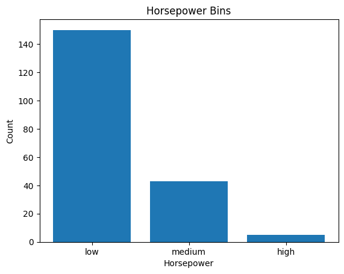

```python
import matplotlib.pyplot as plt  # Make sure you import pyplot correctly

# Assuming you have the 'group_names' defined somewhere in the code
# Plotting the bar chart
plt.bar(group_names, df['horsepower_binned'].value_counts())

# Set x and y labels and title
plt.xlabel('Horsepower')
plt.ylabel('Count')
plt.title('Horsepower Bins')

# Show the plot
plt.show()
```

Now this visulization looks easy to comprehend, as we successfully narrowed down the intervals.

## Bins Visualization

For visualizing the bins, we usually create a **histogram**.

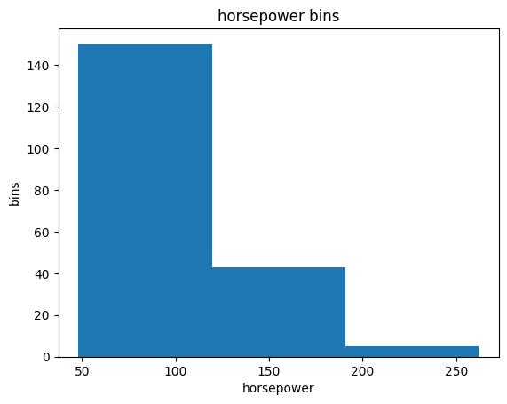

```python
%matplotlib inline
import matplotlib as plt
from matplotlib import pyplot

# draw histogram of attribute 'horsepower' with bins = 3

plt.pyplot.hist(df['horsepower'], bins = 3)

# set X and Y labes with title
plt.pyplot.title("horsepower bins")
plt.pyplot.xlabel("horsepower")
plt.pyplot.ylabel('bins')
```

*Valid the histogram later*

# Indicator Variable

An indicator variable called a **dummy variable**, which is a numerical variable used to label categories.

Called dummies because the numbers that used to represent, it doesn't have inherent meaning or it doesn't resemble the characters of variable.

Used to indicate the variable only.

**Uses**:

For regression analysis

```python
df['fuel-type'].unique()
```

```
array(['gas', 'diesel'], dtype=object)
```

Above in 'fuel-type', there are two unique values "gas" and "diesel". To perform regression analysis, Regression doesn't understand words. This has to be indicate with some numerical values to indicate the specific values.

So 'fuel-type' has to be converted to different two categories of fuel type.

**pd.get_dummies()**

```python
# get the indicator variables of fuel-type and set it to the new df called "dummy_var"

dummy_var= pd.get_dummies(df['fuel-type'])
dummy_var.head()
```

|  | diesel | gas |
| --- | --- | --- |
| 0 | False | True |
| 1 | False | True |
| 2 | False | True |
| 3 | False | True |
| 4 | False | True |

```python
dummy_var.rename(columns= {'gas': 'fuel-type-gas', 'diesel' : 'fuel-type-diesel'}, inplace= True)
dummy_var.head()
```

|  | fuel-type-diesel | fuel-type-gas |
| --- | --- | --- |
| 0 | False | True |
| 1 | False | True |
| 2 | False | True |
| 3 | False | True |
| 4 | False | True |

Intrepretation of the above table:

fuel-type-diesel has been assigned to 0s

fuel-type-gas has been assigned to 1s.

### Merging

Merge original data 'df' and 'dummy variables' dataframe.

**pd.concat()**

```python
df = pd.concat([df, dummy_var], axis= 1)
df.head()
```

|  | symboling | normalized-losses | make | fuel-type | aspiration | num-of-doors | body-style | drive-wheels | engine-location | wheel-base | ... | horsepower | peak-rpm | city-L/100km | highway-L/100km | price | city-L/100km | highway-L/100km | horsepower_binned | fuel-type-diesel | fuel-type-gas |
| --- | --- | --- | --- | --- | --- | --- | --- | --- | --- | --- | --- | --- | --- | --- | --- | --- | --- | --- | --- | --- | --- |
| 0 | 3 | 122 | alfa-romero | gas | std | two | convertible | rwd | front | 88.6 | ... | 111.0 | 5000.0 | 11.190476 | 8.703704 | 16500.0 | 12.142857 | 9.444444 | (47.999, 119.333] | False | True |
| 1 | 1 | 122 | alfa-romero | gas | std | two | hatchback | rwd | front | 94.5 | ... | 154.0 | 5000.0 | 12.368421 | 9.038462 | 16500.0 | 13.421053 | 9.807692 | (119.333, 190.667] | False | True |
| 2 | 2 | 164 | audi | gas | std | four | sedan | fwd | front | 99.8 | ... | 102.0 | 5500.0 | 9.791667 | 7.833333 | 13950.0 | 10.625000 | 8.500000 | (47.999, 119.333] | False | True |
| 3 | 2 | 164 | audi | gas | std | four | sedan | 4wd | front | 99.4 | ... | 115.0 | 5500.0 | 13.055556 | 10.681818 | 17450.0 | 14.166667 | 11.590909 | (47.999, 119.333] | False | True |
| 4 | 2 | 122 | audi | gas | std | two | sedan | fwd | front | 99.8 | ... | 110.0 | 5500.0 | 12.368421 | 9.400000 | 15250.0 | 13.421053 | 10.200000 | (47.999, 119.333] | False | True |

5 rows × 31 columns

### Drop

As we have not remove fuel type column, which we don't need now. So, it would better delete that column.

```python
df.drop('fuel-type', axis = 1, inplace = True)
df.head()
```

|  | symboling | normalized-losses | make | aspiration | num-of-doors | body-style | drive-wheels | engine-location | wheel-base | length | ... | horsepower | peak-rpm | city-L/100km | highway-L/100km | price | city-L/100km | highway-L/100km | horsepower_binned | fuel-type-diesel | fuel-type-gas |
| --- | --- | --- | --- | --- | --- | --- | --- | --- | --- | --- | --- | --- | --- | --- | --- | --- | --- | --- | --- | --- | --- |
| 0 | 3 | 122 | alfa-romero | std | two | convertible | rwd | front | 88.6 | 168.8 | ... | 111.0 | 5000.0 | 11.190476 | 8.703704 | 16500.0 | 12.142857 | 9.444444 | (47.999, 119.333] | False | True |
| 1 | 1 | 122 | alfa-romero | std | two | hatchback | rwd | front | 94.5 | 171.2 | ... | 154.0 | 5000.0 | 12.368421 | 9.038462 | 16500.0 | 13.421053 | 9.807692 | (119.333, 190.667] | False | True |
| 2 | 2 | 164 | audi | std | four | sedan | fwd | front | 99.8 | 176.6 | ... | 102.0 | 5500.0 | 9.791667 | 7.833333 | 13950.0 | 10.625000 | 8.500000 | (47.999, 119.333] | False | True |
| 3 | 2 | 164 | audi | std | four | sedan | 4wd | front | 99.4 | 176.6 | ... | 115.0 | 5500.0 | 13.055556 | 10.681818 | 17450.0 | 14.166667 | 11.590909 | (47.999, 119.333] | False | True |
| 4 | 2 | 122 | audi | std | two | sedan | fwd | front | 99.8 | 177.3 | ... | 110.0 | 5500.0 | 12.368421 | 9.400000 | 15250.0 | 13.421053 | 10.200000 | (47.999, 119.333] | False | True |

5 rows × 30 columns

### Exploring another variables to perform dummies operation

```python
df['aspiration'].unique()
```

```
array(['std', 'turbo'], dtype=object)
```

Two values are there : 'std' and 'turbo'. Apply indicator variable to both of them.

```python
dummy_asp = pd.get_dummies(df['aspiration'])
dummy_asp.head()
```

|  | std | turbo |
| --- | --- | --- |
| 0 | True | False |
| 1 | True | False |
| 2 | True | False |
| 3 | True | False |
| 4 | True | False |

```python
# rename, std and turbo
dummy_asp.rename(columns={'std':'aspiration_std', 'turbo':'aspiration_turbo'}, inplace = True)

# concatenate with origina dataset 'df'
df = pd.concat([df, dummy_asp], axis=1)

# drop the 'aspiration' variable
df.drop('aspiration', axis = 1, inplace = True)
df.head()
```

|  | symboling | normalized-losses | make | num-of-doors | body-style | drive-wheels | engine-location | wheel-base | length | width | ... | city-L/100km | highway-L/100km | price | city-L/100km | highway-L/100km | horsepower_binned | fuel-type-diesel | fuel-type-gas | aspiration_std | aspiration_turbo |
| --- | --- | --- | --- | --- | --- | --- | --- | --- | --- | --- | --- | --- | --- | --- | --- | --- | --- | --- | --- | --- | --- |
| 0 | 3 | 122 | alfa-romero | two | convertible | rwd | front | 88.6 | 168.8 | 64.1 | ... | 11.190476 | 8.703704 | 16500.0 | 12.142857 | 9.444444 | (47.999, 119.333] | False | True | True | False |
| 1 | 1 | 122 | alfa-romero | two | hatchback | rwd | front | 94.5 | 171.2 | 65.5 | ... | 12.368421 | 9.038462 | 16500.0 | 13.421053 | 9.807692 | (119.333, 190.667] | False | True | True | False |
| 2 | 2 | 164 | audi | four | sedan | fwd | front | 99.8 | 176.6 | 66.2 | ... | 9.791667 | 7.833333 | 13950.0 | 10.625000 | 8.500000 | (47.999, 119.333] | False | True | True | False |
| 3 | 2 | 164 | audi | four | sedan | 4wd | front | 99.4 | 176.6 | 66.4 | ... | 13.055556 | 10.681818 | 17450.0 | 14.166667 | 11.590909 | (47.999, 119.333] | False | True | True | False |
| 4 | 2 | 122 | audi | two | sedan | fwd | front | 99.8 | 177.3 | 66.3 | ... | 12.368421 | 9.400000 | 15250.0 | 13.421053 | 10.200000 | (47.999, 119.333] | False | True | True | False |

5 rows × 31 columns

# Saving final dataset

```python
df.to_csv('clean_df.cssv')
```